# R Notebook

```r
library(CodeClanData)
library(tidyverse)
library(janitor)
```

```r
qb_revenue_breakdown

qb_monthly_sales

qb_competitors

qb_device_data
```

```r
qb_revenue_breakdown <- clean_names(qb_revenue_breakdown)

qb_monthly_sales <- clean_names(qb_monthly_sales)

qb_competitors <- clean_names(qb_competitors)

qb_device_data <- clean_names(qb_device_data)
```

# MPV

## 2.1 Part 1

Question 1. Take the data in the dataset qb_revenue_breakdown and make a stacked bar chart showing the sources of revenue across the two years in the dataset.

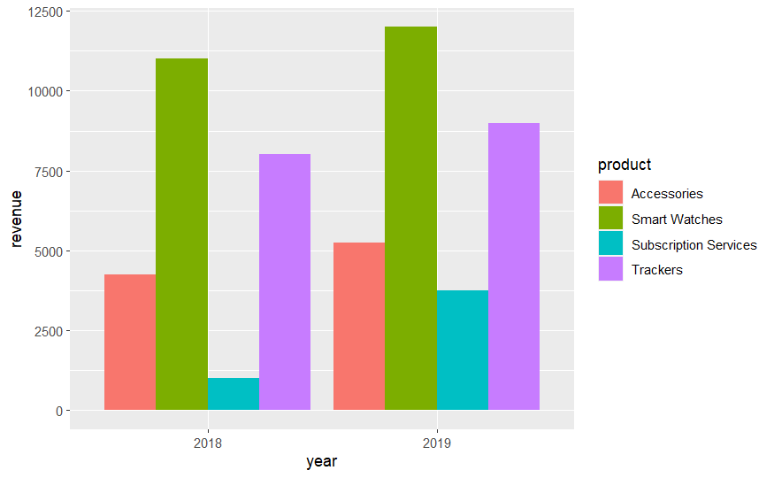

```r
ggplot(qb_revenue_breakdown)+
  geom_col(aes(x = year, y = revenue, fill = product), position = "dodge")
```

Question 2. Make a line chart showing monthly sales of the “flagship product” - the ‘KwikBit Unit 1’ - over the last year. This data is inside qb_monthly_sales, but you will need to use filter() or subset() (base R).

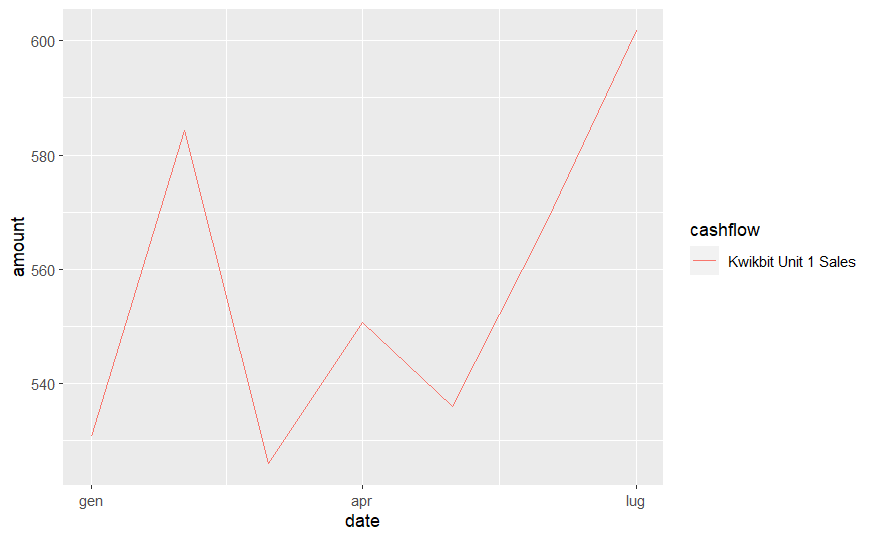

```r
qb_monthly_sales_KwikBit <- qb_monthly_sales %>%
 filter(cashflow == "Kwikbit Unit 1 Sales" & year(date) == 2019)


ggplot(qb_monthly_sales_KwikBit)+
  geom_line(aes(x = date, y = amount, colour = cashflow))
```

Question 3. Make a line chart showing monthly revenue and costs over the last year. This data is also in qb_monthly_sales.

```r
qb_monthly_sales %>%
  filter(cashflow != "Kwikbit Unit 1 Sales" & year(date) == 2019)
```

| date | cashflow | amount |
| --- | --- | --- |
| 2019-07-01 | Total Revenue | 2913.80 |
| 2019-06-01 | Total Revenue | 2565.24 |
| 2019-05-01 | Total Revenue | 2402.93 |
| 2019-04-01 | Total Revenue | 2594.11 |
| 2019-03-01 | Total Revenue | 2422.37 |
| 2019-02-01 | Total Revenue | 2708.77 |
| 2019-01-01 | Total Revenue | 2624.81 |
| 2019-07-01 | Cost | 1693.16 |
| 2019-06-01 | Cost | 1701.26 |
| 2019-05-01 | Cost | 1680.89 |

[output cut: 4 more lines]

```r
remove(qb_monthly_sales_year)
```

```
Avvertimento: object 'qb_monthly_sales_year' not found
```

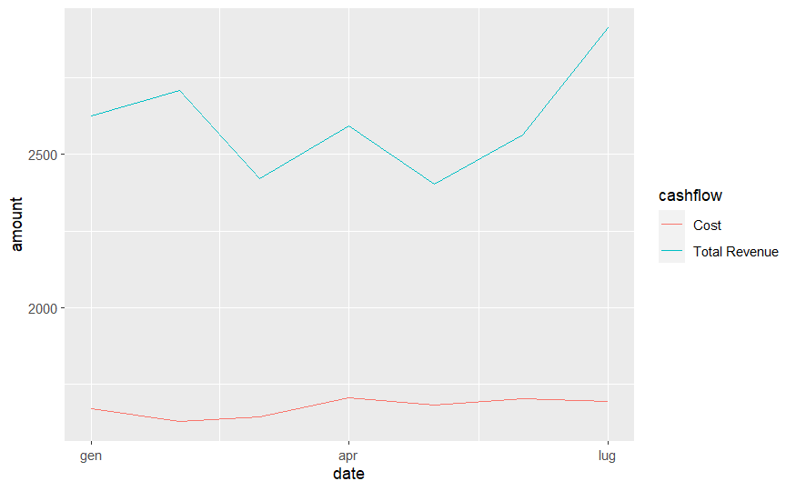

```r
ggplot(qb_monthly_sales %>% filter(year(date) == 2019 & cashflow != "Kwikbit Unit 1 Sales"))+
  geom_line(aes(x = date, y = amount, colour = cashflow))
```

Question 4. Show annual sales of personal fitness trackers over the last 5 years broken down by company as a ribbon plot (use geom_area). This data is in qb_competitors.

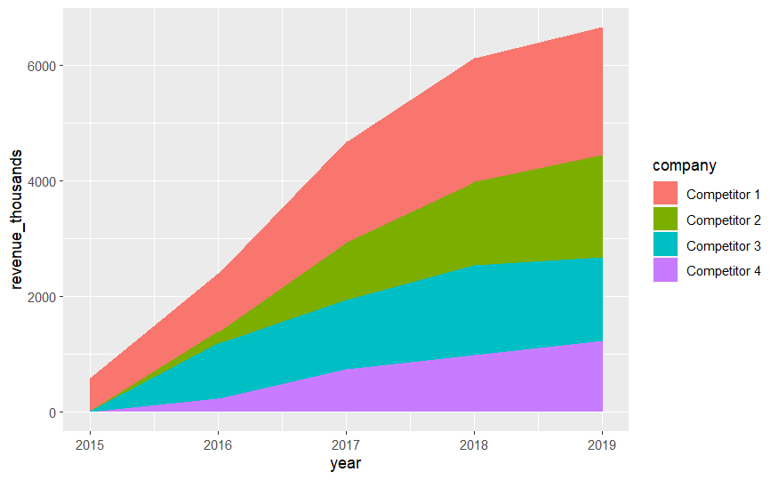

```r
ggplot(qb_competitors %>%
  mutate(revenue_thousands = revenue/1000))+
  geom_area(aes(x = year, y = revenue_thousands, group = company, fill = company))
```

```r
?geom_area
```

Question 5. Now show the sales from the four competitors as a line graph. Include an extra layer that shows the data points used to make the lines.

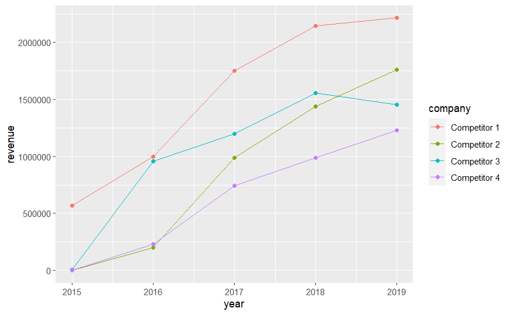

```r
ggplot(qb_competitors)+
    geom_line(aes(x = year, y = revenue, color = company))+
 geom_point(aes(x = year, y = revenue, color = company))
```

Question 6. Now the company wants to compare the number of steps that their device counts vs. their competitors. Make a line graph of the number of steps throughout time, and use faceting to compare between companies and people. The data for this is in qb_device_data.

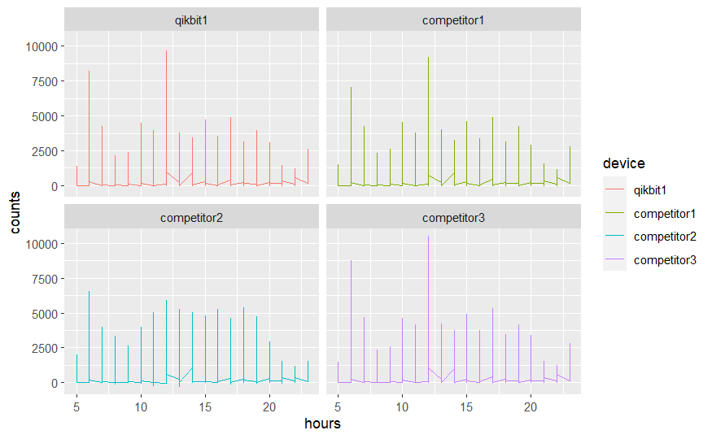

```r
ggplot(qb_device_data)+
  aes(x = hours, y = counts, group = device, colour = device)+
  geom_line()+
  facet_wrap(~device)
```

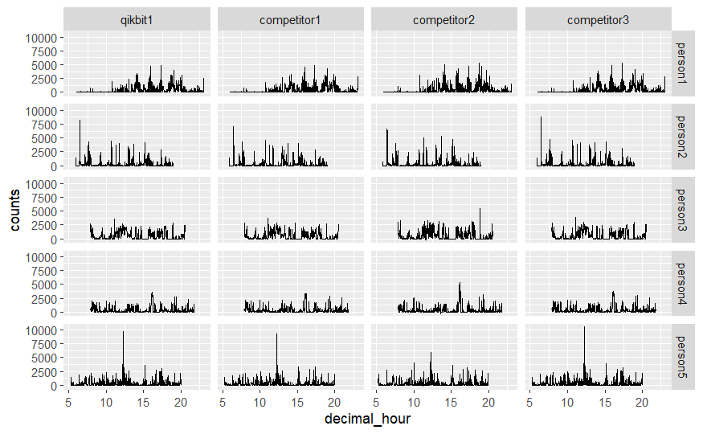

```r
#Correction

qb_device_data <-
mutate(qb_device_data, decimal_hour = hours + (mins/60))

ggplot(qb_device_data) +
  aes(x = decimal_hour, y = counts) +
  geom_line() +
  facet_grid(id ~ device)
```

## 2.2 Part 2

Question 1. Take the plots that you produced in part one and now polish them by:

- Adding appropriate labels
- Changing the scales and coordinates when appropriate.
- Applying a unified theme, which is described below:
- Graphs should have white backgrounds, and use colour sparingly.
- There should be faint grid lines.
- Font sizes should be ~12pt although titles should be slightly larger and axis labels can be slightly smaller.
- All plots should use colours from the following company colour scheme.

```r
col_scheme <- c("#E89FE9", "#50434F", "#B6A7B5", "#F9A472", "#BD7040")
```

# Queation1_Part1

Take the data in the dataset qb_revenue_breakdown and make a stacked bar chart showing the sources of revenue across the two years in the dataset.

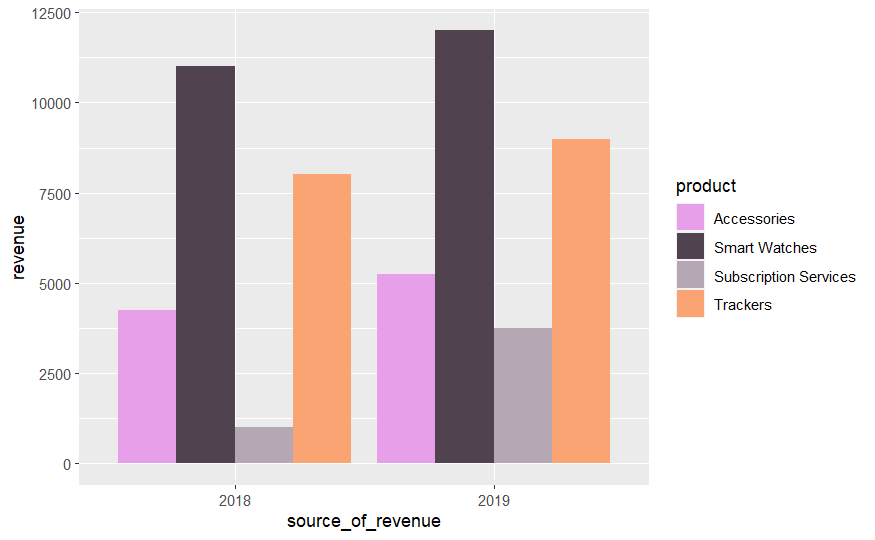

Question 2. Make a line chart showing monthly sales of the “flagship product” - the ‘KwikBit Unit 1’ - over the last year. This data is inside qb_monthly_sales, but you will need to use filter() or subset() (base R).

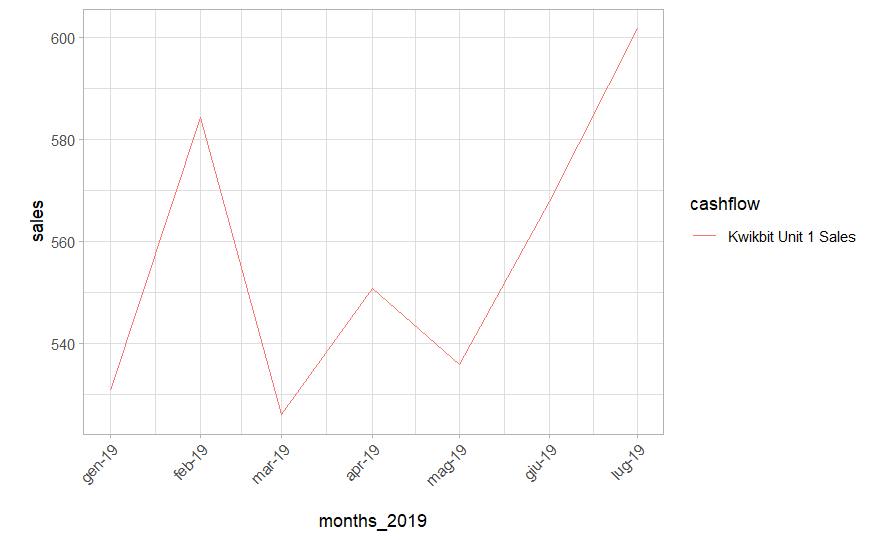

Question 3. Make a line chart showing monthly revenue and costs over the last year. This data is also in qb_monthly_sales.

```r
qb_monthly_sales %>%
  filter(cashflow != "Kwikbit Unit 1 Sales" & year(date) == 2019)
```

| date | cashflow | amount |
| --- | --- | --- |
| 2019-07-01 | Total Revenue | 2913.80 |
| 2019-06-01 | Total Revenue | 2565.24 |
| 2019-05-01 | Total Revenue | 2402.93 |
| 2019-04-01 | Total Revenue | 2594.11 |
| 2019-03-01 | Total Revenue | 2422.37 |
| 2019-02-01 | Total Revenue | 2708.77 |
| 2019-01-01 | Total Revenue | 2624.81 |
| 2019-07-01 | Cost | 1693.16 |
| 2019-06-01 | Cost | 1701.26 |
| 2019-05-01 | Cost | 1680.89 |

[output cut: 4 more lines]

```r
remove(qb_monthly_sales_year)
```

```
Avvertimento: object 'qb_monthly_sales_year' not found
```

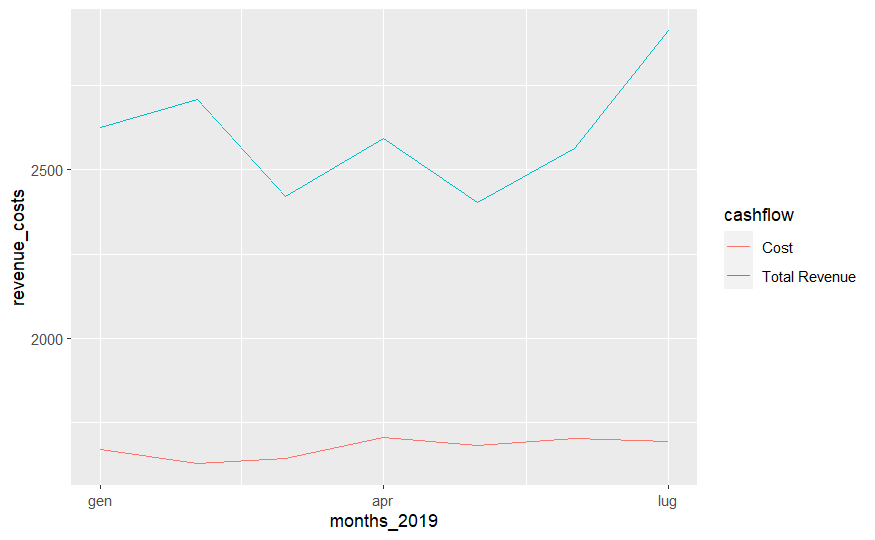

```r
ggplot(qb_monthly_sales %>% filter(year(date) == 2019 & cashflow != "Kwikbit Unit 1 Sales"))+
  geom_line(aes(x = date, y = amount, colour = cashflow))+
  labs(
    x = "months_2019",
    y = "revenue_costs"
  )+
  theme_grey()+
  scale_fill_manual(
    values = c(
      "Cost" = "#F9A472",
      "Total Revenue" = "#E89FE9"
    )
  )
```

```r
?year()
```

Question 4. Show annual sales of personal fitness trackers over the last 5 years broken down by company as a ribbon plot (use geom_area). This data is in qb_competitors.

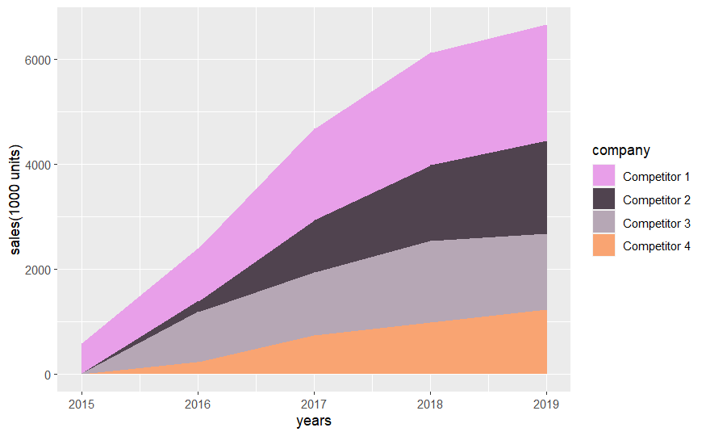

Question 5. Now show the sales from the four competitors as a line graph. Include an extra layer that shows the data points used to make the lines.

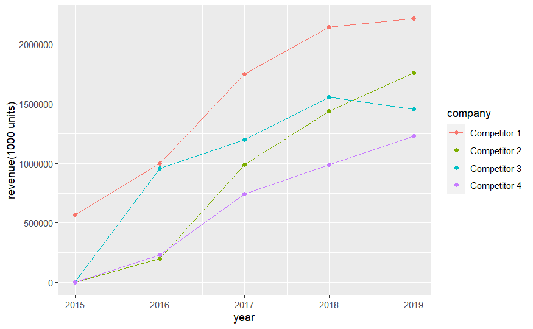

```r
ggplot(qb_competitors)+
    geom_line(aes(x = year, y = revenue, color = company))+
 geom_point(aes(x = year, y = revenue, color = company))+
  labs(
    x = "year",
    y = "revenue(1000 units)"
  )+
  theme_gray()+
  scale_fill_manual(
    values = c(
      "Competitor 1" = "#E89FE9",
      "Competitor 2" = "#50434F",
      "Competitor 3" = "#B6A7B5",
      "Competitor 4" = "#F9A472"
    )
  )
```

Question 6. Now the company wants to compare the number of steps that their device counts vs. their competitors. Make a line graph of the number of steps throughout time, and use faceting to compare between companies and people. The data for this is in qb_device_data.

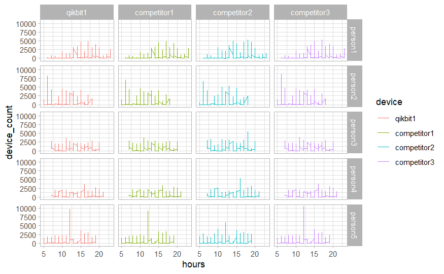

#Correction

```r
theme_qb <-
  theme(
    text = element_text(size = 12),
    title = element_text(size = 14),
    axis.text = element_text(size = 10),
    panel.background = element_rect(fill = "white"),
    panel.grid = element_line(colour = "grey90", linetype = "dashed")
  )
```